# 描述性统计

cui219

2020/6/5

## 2.数据来源及描述性统计

### 2.1数据来源

此次研究所使用的数据来源于狗熊会团队手动整理的数据。数据的指标包括：新增确诊人数、累计确诊人数、现有重症人数、累计死亡人数、累计治愈人数、累计密切解除人数、正在接受医学观察人数、新增密切解除人数、累计报告确诊病例省（区、市）数量。每条数据表示从2020年1月20日至2020年6月3日期间每日疫情的发展情况。原始数据的基本情况如下：

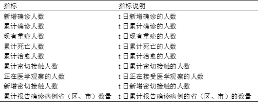

其中，新增确诊人数为每日新增数据，指t日新增的经过核酸检验并确诊为阳性的患者的数目.

### 2.2描述性统计分析

自2020年1月20日至2020年6月3日为止，我国新冠肺炎的累计确诊人数83022人.根据图1可知，新冠肺炎的累计确诊人数在2020年1月20日至2020年1月27日缓慢增长，在2020年1月27日之后我国的新冠肺炎的累计确诊人数以斜率先增加后减小的形式增加，在2020年2月27日之后我国新冠肺炎的累计确诊人数趋于平稳。

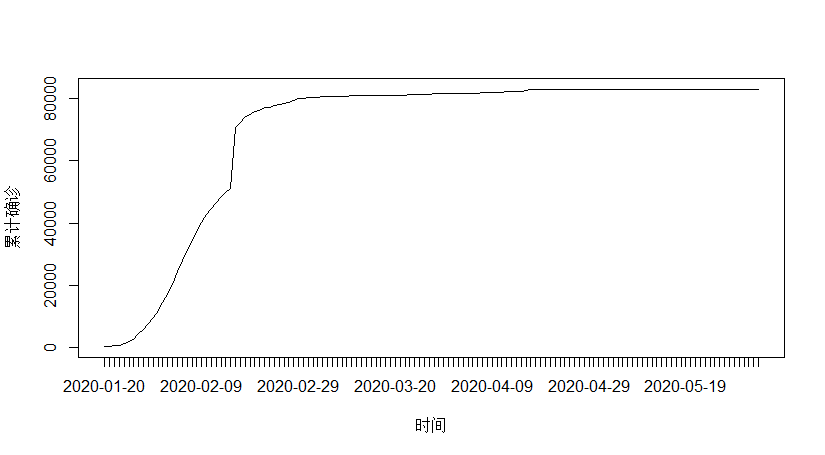

如图2所示，累计治愈人数先以斜率增大的形式增加，后以斜率减小的形式增加，在2020年4月4日之后趋于平缓。在初期，由于人们对新冠肺炎了还不够了解以及患者数目不是很多，所以在初期，累计治愈人数的斜率是小的；在中期，由于人们掌握了新冠肺炎的有效治疗方式和患者人数较多，所以累计治愈人数的斜率有所上升；在后期，由于患者大多数已经治愈，现有患者人数较少，所以累计治愈人数的斜率是趋于平缓的。

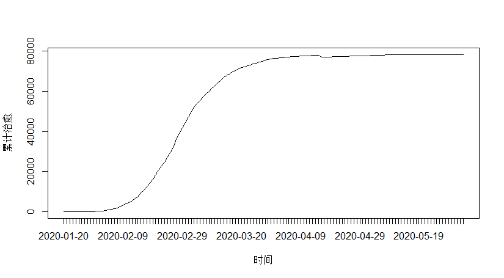

由图3可知，累计死亡人数先以斜率增大的形式增加，后以斜率减小的形式增加，在2020年3月10日趋于平稳。但在2020年4月16日发生了跳跃，这是因为在2020年4月17日对2020年4月16日的湖北省武汉市新冠肺炎疫情数据进行了订正，累计死亡人数核增1290例。

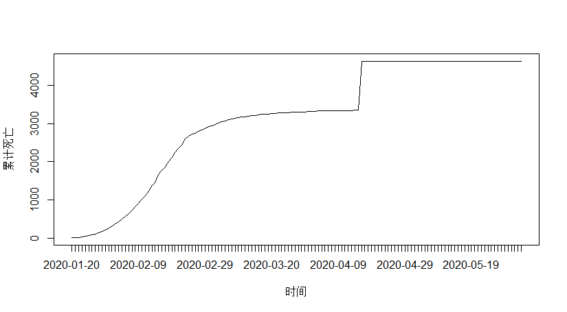

如图4所示，将累计确诊人数、累计治愈人数和累计死亡人数放在同一个图中。我们可以看出，累计治愈人数的曲线远远高于累计死亡人数的曲线，累计治愈人数和累计确诊人数的曲线是非常接近的，由此可知，我国新冠肺炎的治愈率还是比较高的，达94%。

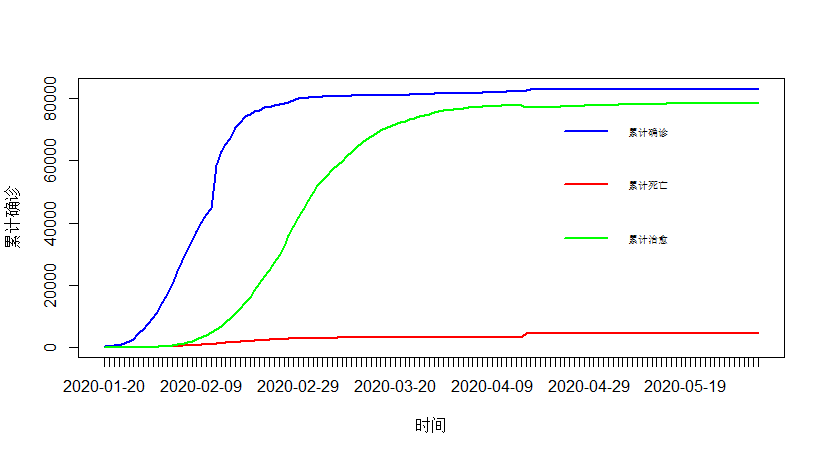

由图5可知，我国新冠肺炎的新增确诊人数先快速增加，在2020年2月4日，达到最高点，新增确诊人数为3887例。在2020年2月4日之后，我国新冠肺炎的新增确诊人数开始下降，直至2020年3月1日，我国新冠肺炎的新增确诊人数趋于平缓。

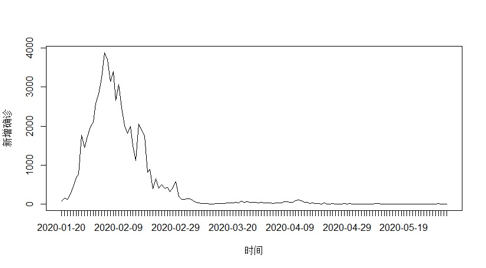

由图6可知，我国新冠肺炎的新增治愈人数先呈现上升的趋势，在2020年2月26日，达到最高点，新增治愈人数为3622例。在2020年2月26日之后，我国新冠肺炎的新增治愈人数开始下降，直至2020年3月30日，我国新冠肺炎的新增治愈人数趋于平缓。在2020年4月16日，我国我国新冠肺炎的新增治愈人数出现了负值，这是由于在2020年4月17日对2020年4月16日的湖北省武汉市新冠肺炎疫情数据进行了订正,而新增治愈人数是通过使用原始数据的累计治愈人数的一阶差分得到的，这就使得2020年4月16日的新增治愈人数受到了疫情数据订正的影响，2020年4月16日的实际新增治愈人数为52例。

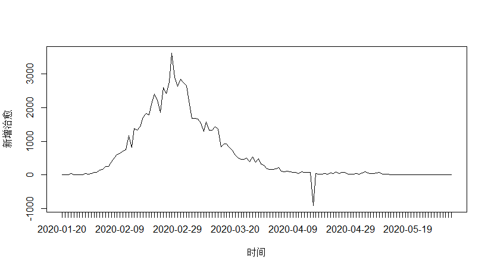

如图7所示，我国新冠肺炎的新增死亡人数先呈现上升的趋势，在2020年2月12日，达到最高点，新增死亡人数为254例。在2020年2月12日之后，我国新冠肺炎的新增死亡人数开始下降，直至2020年2月24日，我国新冠肺炎的新增死亡人数趋于平缓。在2020年4月16日，我国我国新冠肺炎的新增死亡人数出现了异常的趋势，这是由于在2020年4月17日对2020年4月16日的湖北省武汉市新冠肺炎疫情数据进行了订正,而新增死亡人数是通过使用原始数据的累计死亡人数的一阶差分得到的，这就导致2020年4月16日的新增死亡人数受到了疫情数据订正的影响，2020年4月16日的实际新增死亡人数为0例。

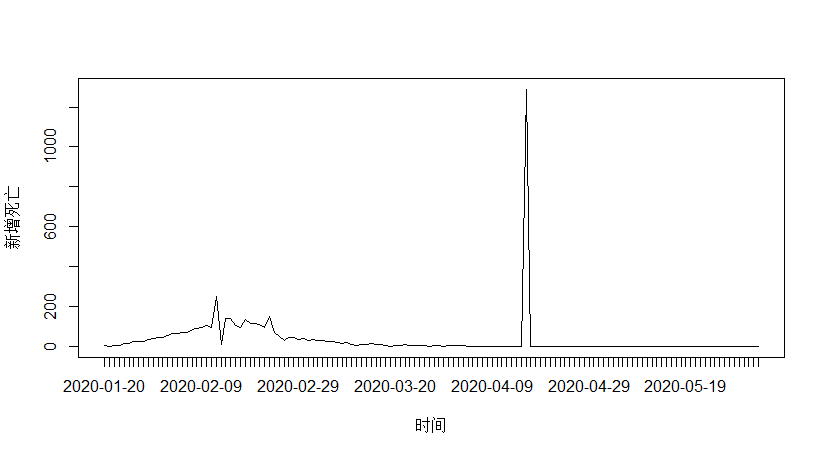

将新增确诊人数、新增治愈人数+新增死亡人数放形成的曲线图和现有确诊的曲线图放在一起形成图8.由图可知，自2020年1月20日至2020年2月18日，新冠肺炎的新增人数确诊大于新增治愈和新增死亡的总人数，此时现有确诊人数上升。自2020年2月18日起，新增确诊人数小于新增治愈和新增死亡的总人数，此时现有确诊人数下降。

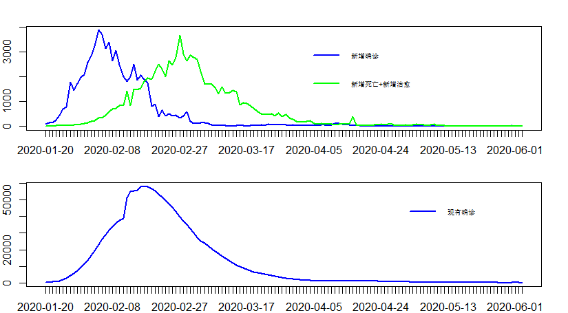